# 20191303 - My data exploration lab notes

# Miniproject - data exploration

[Global Terrorism Database](https://www.kaggle.com/START-UMD/gtd)

Questions:

# Instructions:

1. Download data set, Global Terrorism Database, from https://www.kaggle.com/START-UMD/gtd
2. Take a quick look at the data set. Check what's inside, how the data is structured, and where the data is corrupted (missing values, bad structure, etc).
3. Think and create 5 questions to the data. Try to ask yourself what's really interesting in the data set. What's not so obvious. E.g. some trends, patterns, correlations.
4. Create a jupyter notebook and use python, numpy, pandas, matplotlib (at least) to provide all the answers to your questions.
5. Create a new github repository, and put your jupyter notebook there.
6. Create readme.md file as well in your github root directory with all necessary instructions (what is in the repo, what libs are necessary to run the code, where to find data set and where to save it - this is necessary because the dataset is too big for github repo).
7. Provide the necessary documentation and introduction in your notebook using markdown language, at least: data source description, data structure, importing process, data processing process.
8. Put some data visualization in your notebook. Sometimes it's much easier to present the answer using a chart rather than numbers
9. Check if your notebook run smoothly - use 'Reset & Run All' command from the menu. Save it.
10. Export the notebook as HTML as well, and save the file in the repo.
11. Do not forget to commit/push all the changes to your repo on hithub.
12. Smile :) You did a good job!

FAQ:

1. Can I take a look at different solution provided at kaggle? Yes, you can. But check more than one solution. Try to understand what the authors are trying to solve, and how could it be used in your project. Try to find really good examples - easy to understand and not so complicated. Remember - you create the notebook as an instruction to someone else! Try to not complicate the process.
2. Can I take a look at my friend's solution, that he/she has just put on github? Yes, you can. But it's the smart way of solving the project. I'm sure that you want to be smarter in the next semester - so try to create a better solution and your own one :)
3. Jupyter notebook provide R kernel, so can I use R instead? Nope, R sucks. Even if you love R, try to solve the project using Python.

## Importing data

```python
import pandas as pd
import numpy as np
import matplotlib.pyplot as plt
import seaborn as sns
```

```python
data = pd.read_csv('globalterrorismdb_0718dist.csv',encoding='ISO-8859-1')
data.head()
```

|  | eventid | iyear | imonth | iday | approxdate | extended | resolution | country | country_txt | region | ... | addnotes | scite1 | scite2 | scite3 | dbsource | INT_LOG | INT_IDEO | INT_MISC | INT_ANY | related |
| --- | --- | --- | --- | --- | --- | --- | --- | --- | --- | --- | --- | --- | --- | --- | --- | --- | --- | --- | --- | --- | --- |
| 0 | 197000000001 | 1970 | 7 | 2 | NaN | 0 | NaN | 58 | Dominican Republic | 2 | ... | NaN | NaN | NaN | NaN | PGIS | 0 | 0 | 0 | 0 | NaN |
| 1 | 197000000002 | 1970 | 0 | 0 | NaN | 0 | NaN | 130 | Mexico | 1 | ... | NaN | NaN | NaN | NaN | PGIS | 0 | 1 | 1 | 1 | NaN |
| 2 | 197001000001 | 1970 | 1 | 0 | NaN | 0 | NaN | 160 | Philippines | 5 | ... | NaN | NaN | NaN | NaN | PGIS | -9 | -9 | 1 | 1 | NaN |
| 3 | 197001000002 | 1970 | 1 | 0 | NaN | 0 | NaN | 78 | Greece | 8 | ... | NaN | NaN | NaN | NaN | PGIS | -9 | -9 | 1 | 1 | NaN |
| 4 | 197001000003 | 1970 | 1 | 0 | NaN | 0 | NaN | 101 | Japan | 4 | ... | NaN | NaN | NaN | NaN | PGIS | -9 | -9 | 1 | 1 | NaN |

5 rows × 135 columns

Unfortunately in many records there is sth "Unknown". Let's find out how much is that?

```python
len(data[data['gname']=="Unknown"])/len(data)*100
```

```
45.561970598433604
```

There is around 45% "Unknown's" attackers in the database.

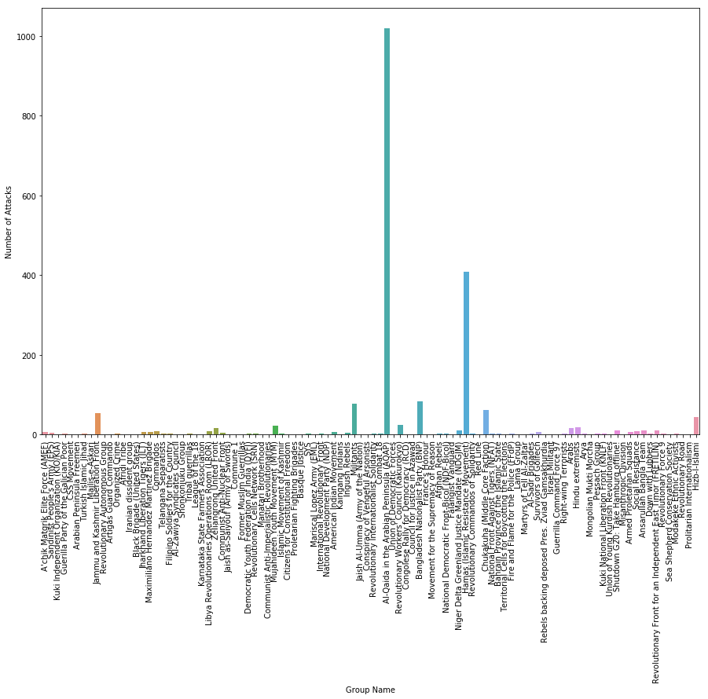

```python
plt.subplots(figsize=(15,10))
no_of_classes = data['gname'].value_counts(sort=True)
no_of_classes_sample = no_of_classes.sample(n=100)
p = sns.barplot(no_of_classes_sample.index,no_of_classes_sample)
p.set(xlabel="Group Name",ylabel="Number of Attacks")
p.set_xticklabels(no_of_classes_sample.index,rotation=90)
plt.show()
```

Let's delete the unknown groups from our database

```python
data = data[data['gname']!='Unknown']
data = data[data['city']!='Unknown']
```

## 2.Number of kills from 1970 to 2017 around the world.

[figure not shown]

```python
data['nkill'].fillna(0)
no_of_kills = data.groupby('iyear')['nkill'].sum()
plt.subplots(figsize=(15,10))
plot1 = sns.barplot(no_of_kills.index,no_of_kills)
plot1.set_xlabel("Year")
plot1.set_ylabel("Number of Kills")
plot1.set_xticklabels(no_of_kills.index,rotation=90)
plt.show()
```

We can observe a little sinusoidal patterns in number of deaths. Unfortunately the peak of deaths is in 21st century.

## 3.Terrorist Activity in every year by Region

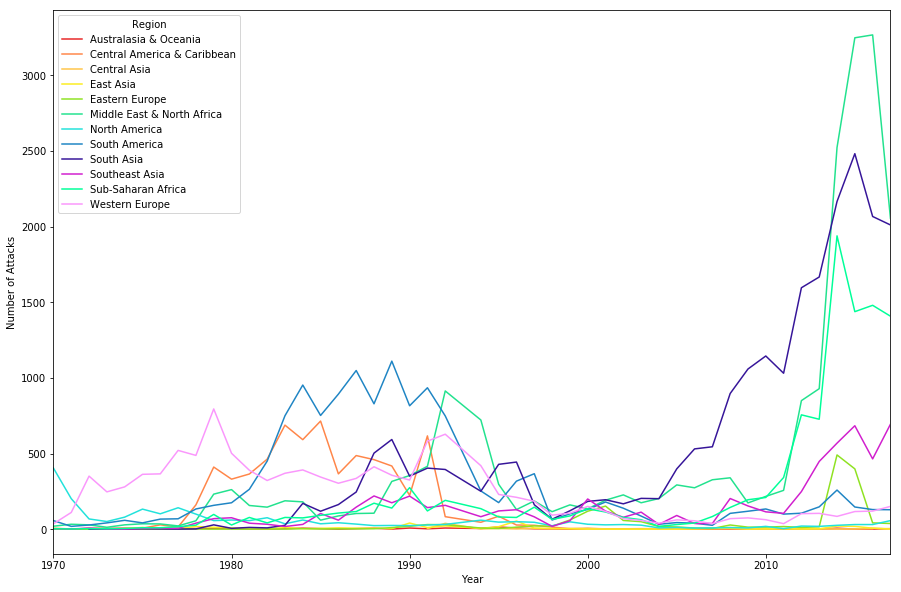

```python
plt.subplots(figsize=(15,10))
d = data.groupby(['region_txt','iyear'])['iyear'].count()
d = pd.DataFrame(d)
d.reset_index(level=0,inplace=True)
d.columns = ['Region','Number of Attacks']
d.reset_index(level=0,inplace=True)
d['dummy']=0
color_set = ["#e82727","#ff8649","#ffc549","#fced20","#8fe222","#22e28e","#22e2db","#1f85c4","#361599","#d11fce","#00ff99","#fa97fc"]
t = sns.tsplot(time='iyear',value='Number of Attacks',condition='Region',data=d,unit='dummy',color = sns.color_palette(color_set))
t.set_xlabel("Year")
plt.show()
```

Based on this chart. We can assume that Australia is the safest continent to live in. Asia, Middle East and North Africa and Sub-Saharan Africa are the most dangerous regions.

## 4.Most dangerous city

Here are the top 10 dangerous cities in 1970-2017

```python
def attacks_terr(data):
    plt.subplots(figsize=(15,10))
    d = pd.DataFrame(data.groupby(['city','iyear'])['iyear'].count())
    d.columns=['Number_of_Attacks']
    d.reset_index(inplace=True)
    d2 = d.loc[d['city'].isin(data['city'].value_counts().sort_values(ascending=False).index[:10])]
    d2 = d2.pivot(index='city',columns='iyear',values='Number_of_Attacks').fillna(0)
    d2 = pd.DataFrame(d2.unstack(level=0))
    d2.reset_index(inplace=True)
    d2.columns=['Year','City','Number of Attacks']
    color_set = ["#e82727","#ff8649","#ffc549","#fced20","#8fe222","#22e28e","#22e2db","#1f85c4","#361599"]
    d2['dummy']=0
    sns.tsplot(time='Year',value='Number of Attacks',condition='City',data=d2,unit='dummy',color = sns.color_palette(color_set))
    plt.show()
```

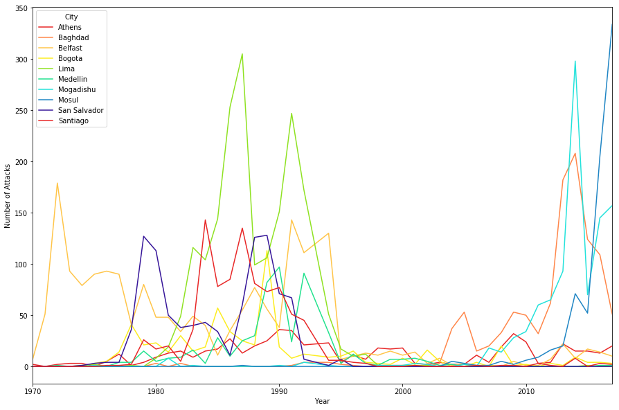

```python
attacks_terr(data)
```

## 5. Statistics about 2017

In 2017 majority of attacks happened within 10 countries.

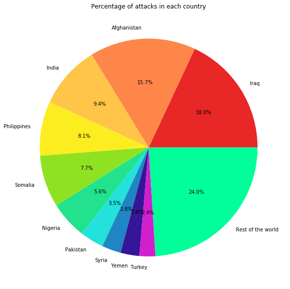

```python
plt.subplots(figsize=(10,10))
d = pd.DataFrame(data[data['iyear']==2017]['country_txt'].value_counts(sort=True)[:10])
d.reset_index(inplace=True)
d.columns=['country','no_of_attacks']
append = ['Rest of the world',sum(data[data['iyear']==2017]['country_txt'].value_counts(sort=True)) - sum(data[data['iyear']==2017]['country_txt'].value_counts(sort=True)[:10])]
d.loc[len(d)]= append
color_set = ["#e82727","#ff8649","#ffc549","#fced20","#8fe222","#22e28e","#22e2db","#1f85c4","#361599","#d11fce","#00ff99","#fa97fc"]
plt.title("Percentage of attacks in each country")
plt.pie(d['no_of_attacks'],labels=d['country'],colors= color_set,autopct='%.1f%%')
plt.show()
```

Another interesting statisic shows that for 2017 more than 85% of deaths due to attacks occured in 10 countries.

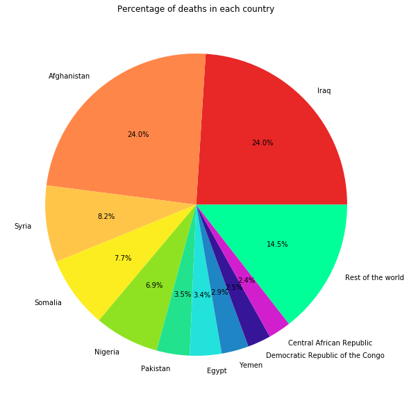

```python
plt.subplots(figsize=(10,10))
d = data[data['iyear']==2017]
d2 = pd.DataFrame(d.groupby('country_txt')['nkill'].sum().sort_values(ascending=False)[:10])
d2.reset_index(inplace=True)
append = ['Rest of the world',(d['nkill'].sum()- d2['nkill'].sum())]
d2.loc[len(d2)] = append
color_set = ["#e82727","#ff8649","#ffc549","#fced20","#8fe222","#22e28e","#22e2db","#1f85c4","#361599","#d11fce","#00ff99","#fa97fc"]
plt.title("Percentage of deaths in each country")
plt.pie(d2['nkill'],labels=d2['country_txt'],colors= color_set,autopct='%.1f%%')
plt.show()
```